**City College of San Francisco**

MATH 108 - Foundations of Data Science

# Lecture 05: Building Tables

Associated Textbook Sections: [5.0, 5.1, 5.2, 5.3](https://inferentialthinking.com/chapters/05/Sequences.html)

## Set Up the Notebook

```python
from datascience import *
import numpy as np
%matplotlib inline
import matplotlib.pyplot as plots
plots.style.use('fivethirtyeight')
```

## Arrays

### Demo: Columns of Tables are Arrays

Import the out-of-date data on skyscrapers from `skyscrapers_v2.csv` as a table and explore the San Francisco content of that table.

```python
skyscrapers = Table.read_table('data/skyscrapers_v2.csv')
skyscrapers
```

| name | material | city | height | completed |
| --- | --- | --- | --- | --- |
| One World Trade Center | mixed/composite | New York City | 541.3 | 2014 |
| Willis Tower | steel | Chicago | 442.14 | 1974 |
| 432 Park Avenue | concrete | New York City | 425.5 | 2015 |
| Trump International Hotel & Tower | concrete | Chicago | 423.22 | 2009 |
| Empire State Building | steel | New York City | 381 | 1931 |
| Bank of America Tower | mixed/composite | New York City | 365.8 | 2009 |
| Stratosphere Tower | concrete | Las Vegas | 350.22 | 1996 |
| Aon Center | steel | Chicago | 346.26 | 1973 |
| John Hancock Center | steel | Chicago | 343.69 | 1969 |
| Chrysler Building | steel | New York City | 318.9 | 1930 |

... (1771 rows omitted)

```python
# sf = skyscrapers.where('city', are.equal_to('San Francisco'))
sf = skyscrapers.where('city', 'San Francisco')
sf.sort('completed', descending=True)
```

| name | material | city | height | completed |
| --- | --- | --- | --- | --- |
| 535 Mission Street | mixed/composite | San Francisco | 115.37 | 2015 |
| 222 Second Street | mixed/composite | San Francisco | 112.78 | 2015 |
| One Rincon Hill North Tower | steel | San Francisco | 165 | 2014 |
| Millennium Tower | concrete | San Francisco | 196.6 | 2009 |
| The Infinity II | concrete | San Francisco | 128.02 | 2009 |
| One Rincon Hill South Tower | concrete | San Francisco | 184.41 | 2008 |
| 555 Mission Street | steel | San Francisco | 148.44 | 2008 |
| The Infinity I | concrete | San Francisco | 106.7 | 2008 |
| San Francisco Federal Building | concrete | San Francisco | 71.32 | 2007 |
| St. Regis San Francisco | concrete | San Francisco | 147.53 | 2005 |

... (51 rows omitted)

```python
heights = sf.column('height')
heights
```

```
array([ 260.        ,  237.44000244,  211.83999634,  196.6000061 ,
        184.41000366,  183.        ,  183.        ,  174.6499939 ,
        173.74000549,  173.42999268,  172.25      ,  172.        ,
        168.        ,  165.        ,  163.97999573,  161.24000549,
        161.24000549,  159.69999695,  152.3999939 ,  150.88000488,
        150.27000427,  149.96000671,  148.44000244,  148.44000244,
        147.52999878,  145.1000061 ,  145.        ,  144.        ,
        142.        ,  133.5       ,  132.8999939 ,  132.69999695,
        132.6000061 ,  129.5       ,  128.02000427,  128.        ,
        127.40000153,  127.        ,  126.        ,  126.        ,
        125.        ,  122.        ,  121.30000305,  115.37000275,
        115.22000122,  114.30000305,  112.77999878,  111.        ,
        108.        ,  106.69999695,  106.37999725,  101.41999817,
        100.58000183,  100.58000183,  100.        ,   98.25      ,
         90.83000183,   86.87000275,   74.68000031,   71.31999969,
         64.        ])
```

```python
np.average(heights)
```

```
139.27442681984814
```

The method used below uses a Python object called a list, as indicated by the square brackets. We will discuss these later.

```python
sf_with_SFT = sf.with_row(['Salesforce Tower', 'Steel', 'San Francisco', 1070.0, 2018])
sf_with_SFT.sort('completed', descending=True)
```

| name | material | city | height | completed |
| --- | --- | --- | --- | --- |
| Salesforce Tower | Steel | San Francisco | 1070 | 2018 |
| 535 Mission Street | mixed/composite | San Francisco | 115.37 | 2015 |
| 222 Second Street | mixed/composite | San Francisco | 112.78 | 2015 |
| One Rincon Hill North Tower | steel | San Francisco | 165 | 2014 |
| Millennium Tower | concrete | San Francisco | 196.6 | 2009 |
| The Infinity II | concrete | San Francisco | 128.02 | 2009 |
| One Rincon Hill South Tower | concrete | San Francisco | 184.41 | 2008 |
| 555 Mission Street | steel | San Francisco | 148.44 | 2008 |
| The Infinity I | concrete | San Francisco | 106.7 | 2008 |
| San Francisco Federal Building | concrete | San Francisco | 71.32 | 2007 |

... (52 rows omitted)

## Ranges

### Ranges

- A range is an array of consecutive numbers
  - `np.arange(stop)`: An array of increasing integers from `0` up to `stop`
  - `np.arange(start, stop)`: An array of increasing integers from `start` up to `stop`
  - `np.arange(start, stop, step)`: A range with step between consecutive values
- The range always includes `start` but excludes `stop`

### Demo: Ranges

Make an array explicitly using `make_array` and then construct it and several others using `np.arange`. Access items in an array using the `item` method. Explore the documentation for `np.arange` and force some common errors.

For those with experience using Python arrays, keep in mind that this course does not use the bracket notation `[]` to access items in an array and that may trigger an error in the auto-grader on assignments.

```python
make_array(0, 1, 2, 3, 4, 5, 6)
```

```
array([0, 1, 2, 3, 4, 5, 6])
```

```python
np.arange(6)
```

```
array([0, 1, 2, 3, 4, 5])
```

```python
np.arange(7)
```

```
array([0, 1, 2, 3, 4, 5, 6])
```

```python
np.arange(1, 7)
```

```
array([1, 2, 3, 4, 5, 6])
```

```python
np.arange(1, 7, 0.5)
```

```
array([ 1. ,  1.5,  2. ,  2.5,  3. ,  3.5,  4. ,  4.5,  5. ,  5.5,  6. ,
        6.5])
```

```python
my_array = np.arange(1, 7, 0.5)
```

```python
my_array.item(0) # first item in the array ... it has index 0
```

```
1.0
```

```python
my_array.item(1)
```

```
1.5
```

```python
my_array[0] #AVOID IN THIS CLASS PLEASE: Use my_array.item(0)
```

```
1.0
```

```python
type(my_array)
```

```
numpy.ndarray
```

### Ways to Create a Table

- `Table.read_table(filename)` - reads a table from a csv file
- `Table()` - an empty table
- and… `select`, `drop`, `where`, `sort` and a few other table methods all create new tables
- The table methods `with_column` and `with_columns` adds column(s) to the end of the table and creates a new table.

### Demo: Creating a Table from Scratch

Create a table containing information on the major east-west streets north of the Ocean campus and how far they are from campus. Make sure how to see that most table methods will end up creating a new table and not modify the original one.

[Google Maps near CCSF - Ocean Campus](https://goo.gl/maps/QVR57VvqKWqLeSA9A)

```python
streets = make_array('Judson', 'Staples', 'Flood', 'Hearst')
northside = Table().with_column('Street', streets)
northside
```

| Street |
| --- |
| Judson |
| Staples |
| Flood |
| Hearst |

```python
northside = northside.with_column(
    'Blocks from campus',
    np.arange(4)
)
```

There are various properties of a table that you can access as well using the dot notation such as `labels`, `num_columns`, and `num_rows`.

```python
northside.labels
```

```
('Street', 'Blocks from campus')
```

```python
northside.num_rows
```

```
4
```

```python
northside.num_columns
```

```
2
```

## Example: W. E. B. Du Bois

Image Source: [Wikipedia - W. E. B. Du Bois](https://en.wikipedia.org/wiki/W._E._B._Du_Bois)

[figure not shown]

**The content of the following podcast, video, and images contains references to slavery, lynching, and the historical use of the word negro.**

- Scholar, historian, activist, and data scientist

  > "The Philadelphia Negro was the first scientific study of race in the world. [...] the first non-racist investigation of a non-white poulation in the world. [...] one of the first social scientific written in the U.S. using the advanced statistical methods of the time." - Dr. Tukufu Zuberi, Professor of Race Relations at the University of Pennsylvania (Source: [A Legacy of Courage: W.E.B. Du Bois and the Philadelphia Negro](https://youtu.be/PQX_0uyDgGw))
- First Black American to receive a PhD from Harvard
- NAACP founder
- Made a series of visualizations for the 1900 Paris Exposition
  - Goal: change the way people see Black Americans
  - Hundreds of photographs and patents
  - 60+ handmade graphs in 3 months

    > "All art is propaganda, and ever must be, despite the wailing of the purists. I stand in utter shamelessness and say that whatever art I have for writing has been used always for propaganda for gaining the right of black folk to love and enjoy. I do not care a damn for any art that is not used for propaganda." - W.E.B. Du Bois
- Typically compared with Booker T. Washington.

The following podcast provides an 11 minutes overview of these two leaders.

```python
# The content contains references to slavery, lynching, and the historical use of the word negro.
from IPython.display import IFrame
IFrame('https://open.spotify.com/embed/episode/6MdipyUuPK2bbXF0n2CYA1?utm_source=generator', width=500, height=350)
```

[interactive chart not shown]

### Images from Paris Exposition

Image Sources:

- [Smithsonian Magazine - W.E.B. Du Bois’ Visionary Infographics Come Together for the First Time in Full Color](https://www.smithsonianmag.com/history/first-time-together-and-color-book-displays-web-du-bois-visionary-infographics-180970826/#)
- [WBUR - W.E.B. Du Bois Created These Infographics In 1900 To Humanize The African-American Experience](https://www.wbur.org/news/2019/02/21/web-du-bois-infographics-humanity-african-american)

[figure not shown]

### Demo: Reading a Table from a File

Read the `du_bois.csv` data as a table.

```python
du_bois = Table.read_table('data/du_bois.csv')
du_bois
```

| CLASS | ACTUAL AVERAGE | RENT | FOOD | CLOTHES | TAXES | OTHER | STATUS |
| --- | --- | --- | --- | --- | --- | --- | --- |
| 100-200 | 139.1 | 0.19 | 0.43 | 0.28 | 0.001 | 0.099 | POOR |
| 200-300 | 249.45 | 0.22 | 0.47 | 0.23 | 0.04 | 0.04 | POOR |
| 300-400 | 335.66 | 0.23 | 0.43 | 0.18 | 0.045 | 0.115 | FAIR |
| 400-500 | 433.82 | 0.18 | 0.37 | 0.15 | 0.055 | 0.245 | FAIR |
| 500-750 | 547 | 0.13 | 0.31 | 0.17 | 0.05 | 0.34 | COMFORTABLE |
| 750-1000 | 880 | 0 | 0.37 | 0.19 | 0.08 | 0.36 | COMFORTABLE |
| 1000 and over | 1125 | 0 | 0.29 | 0.16 | 0.045 | 0.505 | WELL-TO-DO |

Find the income bracket (`CLASS`) that spent the highest percentage of their income on rent.

```python
# This task is common in the class!
du_bois_sorted = du_bois.sort('RENT', descending=True)
classes = du_bois_sorted.column('CLASS')
classes.item(0)
```

```
'300-400'
```

THE FOLLOWING WAS NOT DEMONSTRATED LIVE, BUT IT IS HERE FOR REFERENCE

Explore the table using `select`, `column`

```python
du_bois.select('STATUS')
```

| STATUS |
| --- |
| POOR |
| POOR |
| FAIR |
| FAIR |
| COMFORTABLE |
| COMFORTABLE |
| WELL-TO-DO |

```python
du_bois.column('STATUS')
```

```
array(['POOR', 'POOR', 'FAIR', 'FAIR', 'COMFORTABLE', 'COMFORTABLE',
       'WELL-TO-DO'],
      dtype='<U11')
```

Add a column to the table showing the dollar amount for food based on the presented average.

```python
du_bois.column('ACTUAL AVERAGE') * du_bois.column('FOOD')
```

```
array([  59.813 ,  117.2415,  144.3338,  160.5134,  169.57  ,  325.6   ,
        326.25  ])
```

```python
food_dollars = du_bois.column('ACTUAL AVERAGE') * du_bois.column('FOOD')
du_bois = du_bois.with_column(
    'Food $',
    food_dollars
)
du_bois
```

| CLASS | ACTUAL AVERAGE | RENT | FOOD | CLOTHES | TAXES | OTHER | STATUS | Food $ |
| --- | --- | --- | --- | --- | --- | --- | --- | --- |
| 100-200 | 139.1 | 0.19 | 0.43 | 0.28 | 0.001 | 0.099 | POOR | 59.813 |
| 200-300 | 249.45 | 0.22 | 0.47 | 0.23 | 0.04 | 0.04 | POOR | 117.241 |
| 300-400 | 335.66 | 0.23 | 0.43 | 0.18 | 0.045 | 0.115 | FAIR | 144.334 |
| 400-500 | 433.82 | 0.18 | 0.37 | 0.15 | 0.055 | 0.245 | FAIR | 160.513 |
| 500-750 | 547 | 0.13 | 0.31 | 0.17 | 0.05 | 0.34 | COMFORTABLE | 169.57 |
| 750-1000 | 880 | 0 | 0.37 | 0.19 | 0.08 | 0.36 | COMFORTABLE | 325.6 |
| 1000 and over | 1125 | 0 | 0.29 | 0.16 | 0.045 | 0.505 | WELL-TO-DO | 326.25 |

Format the `Food` column as a percent using the `set_format` method.

```python
du_bois.set_format('FOOD', PercentFormatter)
```

| CLASS | ACTUAL AVERAGE | RENT | FOOD | CLOTHES | TAXES | OTHER | STATUS | Food $ |
| --- | --- | --- | --- | --- | --- | --- | --- | --- |
| 100-200 | 139.1 | 0.19 | 43.00% | 0.28 | 0.001 | 0.099 | POOR | 59.813 |
| 200-300 | 249.45 | 0.22 | 47.00% | 0.23 | 0.04 | 0.04 | POOR | 117.241 |
| 300-400 | 335.66 | 0.23 | 43.00% | 0.18 | 0.045 | 0.115 | FAIR | 144.334 |
| 400-500 | 433.82 | 0.18 | 37.00% | 0.15 | 0.055 | 0.245 | FAIR | 160.513 |
| 500-750 | 547 | 0.13 | 31.00% | 0.17 | 0.05 | 0.34 | COMFORTABLE | 169.57 |
| 750-1000 | 880 | 0 | 37.00% | 0.19 | 0.08 | 0.36 | COMFORTABLE | 325.6 |
| 1000 and over | 1125 | 0 | 29.00% | 0.16 | 0.045 | 0.505 | WELL-TO-DO | 326.25 |

### Table Methods

- Creating and extending tables: `Table().with_column` and `Table.read_table`
- Finding the size: `num_rows` and `num_columns`
- Referring to columns: labels, relabeling, and indices
  - `labels` and `relabeled`; column indices start at 0
- Accessing data in a column: `column` takes a label or index and returns an array
- Using array methods to work with data in columns: `item`, `sum`, `min`, `max`, and so on
- Creating new tables containing some of the original columns: `select`, `drop`

### Demo: Selecting Data in a Column

Run the following commands to explore the `movies_by_year_with_ticket_price.csv` data set using several of the methods used so far. Also, preview the `plot` method.

```python
movies = Table.read_table('data/movies_by_year_with_ticket_price.csv')
movies.show()
```

| Year | Average Ticket Price | Total Gross | Number of Movies | #1 Movie |
| --- | --- | --- | --- | --- |
| 2019 | 9.16 | 11237.9 | 788 | Avengers: Endgame |
| 2018 | 9.11 | 11611.3 | 878 | Black Panther |
| 2017 | 8.97 | 11125.4 | 740 | Star Wars: Episode VIII - The Last Jedi |
| 2016 | 8.65 | 11373.7 | 737 | Rogue One: A Star Wars Story |
| 2015 | 8.43 | 11098.8 | 706 | Star Wars: Episode VII - The Force Awakens |
| 2014 | 8.17 | 10436.8 | 708 | American Sniper |
| 2013 | 8.13 | 10955.9 | 689 | The Hunger Games: Catching Fire |
| 2012 | 7.96 | 10959.6 | 669 | The Avengers |
| 2011 | 7.93 | 10114.1 | 601 | Harry Potter and the Deathly Hallows: Part 2 |
| 2010 | 7.89 | 10212.7 | 538 | Toy Story 3 |
| 2009 | 7.5 | 10821.6 | 520 | Avatar |
| 2008 | 7.18 | 9698.2 | 607 | The Dark Knight |
| 2007 | 6.88 | 9690.7 | 632 | Spider-Man 3 |
| 2006 | 6.55 | 9214.6 | 608 | Pirates of the Caribbean: Dead Man's Chest |
| 2005 | 6.41 | 8804.7 | 547 | Star Wars: Episode III - Revenge of the Sith |
| 2004 | 6.21 | 9321.7 | 551 | Shrek 2 |
| 2003 | 6.03 | 9057.5 | 506 | The Lord of the Rings: The Return of the King |
| 2002 | 5.8 | 9206.4 | 480 | Spider-Man |
| 2001 | 5.65 | 8070 | 356 | Harry Potter and the Sorcerer's Stone |
| 2000 | 5.39 | 7678.3 | 371 | How the Grinch Stole Christmas |
| 1999 | 5.06 | 7316.7 | 385 | Star Wars: Episode I - The Phantom Menace |
| 1998 | 4.69 | 6575.8 | 336 | Saving Private Ryan |
| 1997 | 4.59 | 6671.8 | 303 | Titanic |
| 1996 | 4.42 | 5706.7 | 310 | Independence Day |
| 1995 | 4.35 | 5383.5 | 279 | Toy Story |
| 1994 | 4.08 | 5079.2 | 254 | Forrest Gump |
| 1993 | 4.14 | 4983.2 | 258 | Jurassic Park |
| 1992 | 4.15 | 4603.9 | 234 | Aladdin |
| 1991 | 4.21 | 4313.9 | 244 | Terminator 2: Judgment Day |
| 1990 | 4.22 | 4527 | 224 | Home Alone |
| 1989 | 3.99 | 4155.4 | 236 | Batman |
| 1988 | 4.11 | 3565.8 | 248 | Rain Man |
| 1987 | 3.91 | 3562.9 | 232 | Three Men and a Baby |
| 1986 | 3.71 | 3200.5 | 207 | Top Gun |
| 1985 | 3.55 | 3056.4 | 180 | Back to the Future |
| 1984 | 3.36 | 3347.7 | 165 | Beverly Hills Cop |
| 1983 | 3.15 | 2652.9 | 158 | Star Wars: Episode VI - Return of the Jedi |
| 1982 | 2.94 | 2866.2 | 131 | E.T. the Extra-Terrestrial |
| 1981 | 2.78 | 2281.9 | 112 | Raiders of the Lost Ark |
| 1980 | 2.69 | 2299 | 115 | Star Wars: Episode V - The Empire Strikes Back |
| 1979 | 2.47 | 1957.5 | 83 | Kramer vs. Kramer |
| 1978 | 2.34 | 1552.3 | 55 | Grease |
| 1977 | 2.23 | 1373.1 | 35 | Star Wars: Episode IV - A New Hope |

```python
gross_in_dollars = movies.column('Total Gross') * 1e6
tix_sold = gross_in_dollars / movies.column('Average Ticket Price')
```

```python
movies = movies.with_column('Tickets sold', tix_sold)
```

```python
movies.show(4)
```

| Year | Average Ticket Price | Total Gross | Number of Movies | #1 Movie | Tickets sold |
| --- | --- | --- | --- | --- | --- |
| 2019 | 9.16 | 11237.9 | 788 | Avengers: Endgame | 1.22684e+09 |
| 2018 | 9.11 | 11611.3 | 878 | Black Panther | 1.27457e+09 |
| 2017 | 8.97 | 11125.4 | 740 | Star Wars: Episode VIII - The Last Jedi | 1.24029e+09 |
| 2016 | 8.65 | 11373.7 | 737 | Rogue One: A Star Wars Story | 1.31488e+09 |

... (39 rows omitted)

```python
movies.set_format('Tickets sold', NumberFormatter)
```

| Year | Average Ticket Price | Total Gross | Number of Movies | #1 Movie | Tickets sold |
| --- | --- | --- | --- | --- | --- |
| 2019 | 9.16 | 11237.9 | 788 | Avengers: Endgame | 1,226,844,978.17 |
| 2018 | 9.11 | 11611.3 | 878 | Black Panther | 1,274,566,410.54 |
| 2017 | 8.97 | 11125.4 | 740 | Star Wars: Episode VIII - The Last Jedi | 1,240,289,855.07 |
| 2016 | 8.65 | 11373.7 | 737 | Rogue One: A Star Wars Story | 1,314,878,612.72 |
| 2015 | 8.43 | 11098.8 | 706 | Star Wars: Episode VII - The Force Awakens | 1,316,583,629.89 |
| 2014 | 8.17 | 10436.8 | 708 | American Sniper | 1,277,454,100.37 |
| 2013 | 8.13 | 10955.9 | 689 | The Hunger Games: Catching Fire | 1,347,589,175.89 |
| 2012 | 7.96 | 10959.6 | 669 | The Avengers | 1,376,834,170.85 |
| 2011 | 7.93 | 10114.1 | 601 | Harry Potter and the Deathly Hallows: Part 2 | 1,275,422,446.41 |
| 2010 | 7.89 | 10212.7 | 538 | Toy Story 3 | 1,294,385,297.85 |

... (33 rows omitted)

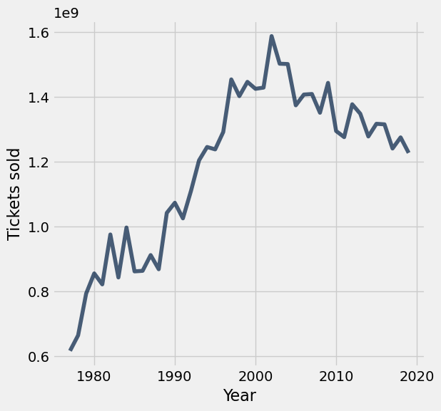

```python
movies.plot('Year', 'Tickets sold')
```

```python
movies.where('Year', are.between(2000, 2005))
```

| Year | Average Ticket Price | Total Gross | Number of Movies | #1 Movie | Tickets sold |
| --- | --- | --- | --- | --- | --- |
| 2004 | 6.21 | 9321.7 | 551 | Shrek 2 | 1,501,078,904.99 |
| 2003 | 6.03 | 9057.5 | 506 | The Lord of the Rings: The Return of the King | 1,502,072,968.49 |
| 2002 | 5.8 | 9206.4 | 480 | Spider-Man | 1,587,310,344.83 |
| 2001 | 5.65 | 8070 | 356 | Harry Potter and the Sorcerer's Stone | 1,428,318,584.07 |
| 2000 | 5.39 | 7678.3 | 371 | How the Grinch Stole Christmas | 1,424,545,454.55 |

```python
movies.where('Year', 2002)
```

| Year | Average Ticket Price | Total Gross | Number of Movies | #1 Movie | Tickets sold |
| --- | --- | --- | --- | --- | --- |
| 2002 | 5.8 | 9206.4 | 480 | Spider-Man | 1,587,310,344.83 |

```python
movies.where('Year', are.equal_to(2002))
```

| Year | Average Ticket Price | Total Gross | Number of Movies | #1 Movie | Tickets sold |
| --- | --- | --- | --- | --- | --- |
| 2002 | 5.8 | 9206.4 | 480 | Spider-Man | 1,587,310,344.83 |

```python
movies.where('#1 Movie', are.containing('Harry Potter'))
```

| Year | Average Ticket Price | Total Gross | Number of Movies | #1 Movie | Tickets sold |
| --- | --- | --- | --- | --- | --- |
| 2011 | 7.93 | 10114.1 | 601 | Harry Potter and the Deathly Hallows: Part 2 | 1,275,422,446.41 |
| 2001 | 5.65 | 8070 | 356 | Harry Potter and the Sorcerer's Stone | 1,428,318,584.07 |

```python
movies.take(np.arange(2, 5))
```

| Year | Average Ticket Price | Total Gross | Number of Movies | #1 Movie | Tickets sold |
| --- | --- | --- | --- | --- | --- |
| 2017 | 8.97 | 11125.4 | 740 | Star Wars: Episode VIII - The Last Jedi | 1,240,289,855.07 |
| 2016 | 8.65 | 11373.7 | 737 | Rogue One: A Star Wars Story | 1,314,878,612.72 |
| 2015 | 8.43 | 11098.8 | 706 | Star Wars: Episode VII - The Force Awakens | 1,316,583,629.89 |